## 7) Feature Engineering

#### **7.1) Word2vec**

Word2Vec is a technique of natural language processing which uses a neural network model to learn word association from a large corpus of data. As the name suggests, word2vec represents each word with a list of numbers called a vector. These vectors of each word can be represented in multiple dimensions and are chosen by the model in a way that various mathematical functions like cosine similarity etc can be applied which helps in understanding the semantic similarity between the words.

We used word2vec package in R to get the word embedding:

The package allows:  
1. To train word embedding using multiple threads on character data or data in a text file.  
2. Use the embedding to find relations between words.

Here we have defined a Hate Speech vector with some custom hate words like “Hate”, “Criticism”, “Discrimination”, “Violent”, “race”,”abuse”,”threat” etc. After the word2vec model was trained , the generated embeddings are used to predict the nearest neighbours by calculating the cosine distance to this hate speech vector and are clustered together using the hierarchical clustering. Here is the plot for the same:

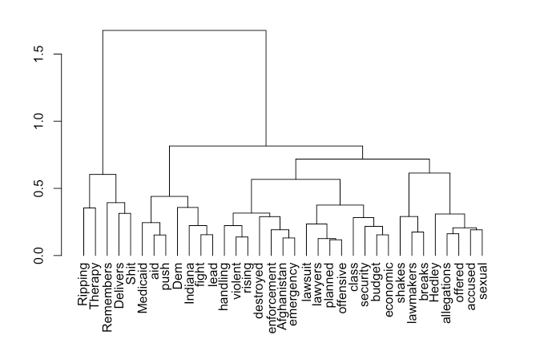

Cluster Dendogram of Words Closest to HateSpeech Vector

```r
dendo <- embedding[unlist(lapply(lookslike, `[`, 'term2')), ]
dendo_dist = dist.cosine(dendo) %>% as.dist
plot(as.dendrogram(hclust(dendo_dist)), horiz=F, cex=1, main="Cluster Dendogram of words closest to HateSpeech Vector")
```

The embeddings generated from word2vec are vectors of each word in 25 dimensions thus we performed dimensionality reduction using UMAP (Uniform Manifold Approximation and Projection for Dimension Reduction) and then they are visualized.

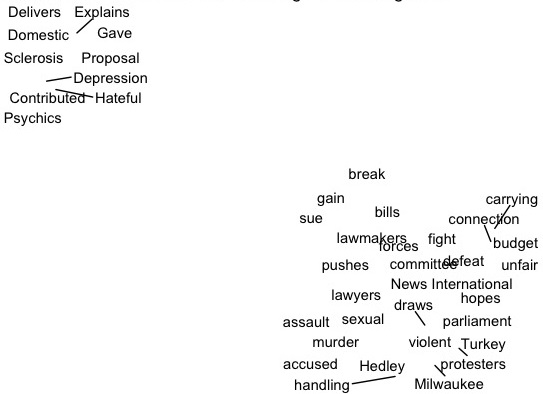

Visualization of Embeddings in 2D using UMAP

```r
ggplot(df, aes(x = x, y = y, label = word)) +
  geom_text_repel() + theme_void() +
  labs(title = "word2vec - Visualization of Embeddings in 2D using UMAP")
```

The reduced dimensions are used to create an interactive scatter plot which will depict the correlations of the words to each other.

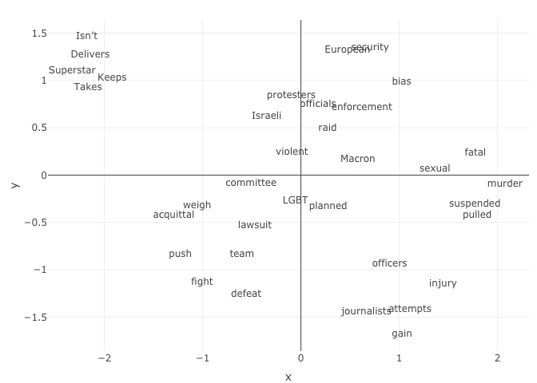

Topics Related to Tweets

```r
plot_ly(df, x = ~x, y = ~y, type = "scatter", mode = 'text', text = ~word)
```

#### **7.2) Glove**

We used Pre-trained Glove embeddings trained on twitter dataset as tweets tend to be short and therefore capturing global word-word occurrence statistics can best be captured if baseline dataset also exhibits the same structure.  
Each tweet by the author is represented as a vector of 25 Dimension. We decided for a 25 dimension vector as dimensions larger than 25 require more storage and computation time.

Steps Followed to get Vector of each Tweet:  
1. Preprocessing of tweets - which includes removing stop words, punctuations , hyphens, numerics and unwanted wanted words like HASHTAG, USERS followed by Tokenization of words in tweets.  
2. For every token in a tweet , get a vector of 25 dimensions using pre-trained GLOVE data.  
3. Summing all vectors, followed by dividing by the total number of words in a tweet. This gives us a Tweet vector.

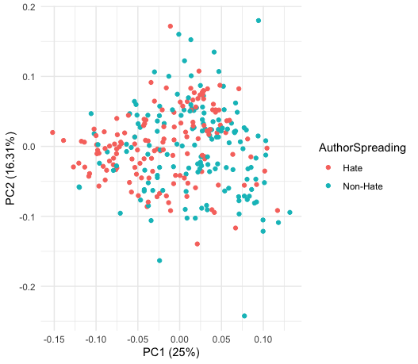

PCA Reduced Scatterplot For Authors per Target Class

```r
authSig.pca <- prcomp(authorSignatures,  center = TRUE,scale. = TRUE)
autoplot(authSig.pca, data = dataset, colour = 'AuthorSpreading')
```

Since , Each author is labelled as Hate spreader or non hate spreader based upon the results of his/her tweets combined. Therefore, We also tried to plot Authors Signatures ( obtained by combining all his/her tweet’s vectors) . We used PCA to reduce dimensions for plotting the result as a scatterplot. We are not able to get much insights and separation of the classes from the scatterplot , classes seem to be overlapped.